# What is Feature Scaling?

It refers to putting the values in the same range or same scale so that no variable is dominated by the other.

# Why Scaling

Most of the times, your dataset will contain features highly varying in magnitudes, units and range.

```python
import numpy as np
import pandas as pd
import matplotlib
import matplotlib.pyplot as plt
import seaborn as sns

matplotlib.style.use('fivethirtyeight')
%matplotlib inline
```

```python
cd=('C:/Users/Windows/Downloads')
```

```python
df = pd.read_csv("diabetes.csv")
```

```python
df.info()
```

```
<class 'pandas.core.frame.DataFrame'>
RangeIndex: 768 entries, 0 to 767
Data columns (total 9 columns):
 #   Column                    Non-Null Count  Dtype
---  ------                    --------------  -----
 0   Pregnancies               768 non-null    int64
 1   Glucose                   768 non-null    int64
 2   BloodPressure             768 non-null    int64
 3   SkinThickness             768 non-null    int64
 4   Insulin                   768 non-null    int64
 5   BMI                       768 non-null    float64
 6   DiabetesPedigreeFunction  768 non-null    float64
 7   Age                       768 non-null    int64
 8   Outcome                   768 non-null    int64
dtypes: float64(2), int64(7)
memory usage: 54.1 KB
```

```python
df.describe()
```

|  | Pregnancies | Glucose | BloodPressure | SkinThickness | Insulin | BMI | DiabetesPedigreeFunction | Age | Outcome |
| --- | --- | --- | --- | --- | --- | --- | --- | --- | --- |
| count | 768.000000 | 768.000000 | 768.000000 | 768.000000 | 768.000000 | 768.000000 | 768.000000 | 768.000000 | 768.000000 |
| mean | 3.845052 | 120.894531 | 69.105469 | 20.536458 | 79.799479 | 31.992578 | 0.471876 | 33.240885 | 0.348958 |
| std | 3.369578 | 31.972618 | 19.355807 | 15.952218 | 115.244002 | 7.884160 | 0.331329 | 11.760232 | 0.476951 |
| min | 0.000000 | 0.000000 | 0.000000 | 0.000000 | 0.000000 | 0.000000 | 0.078000 | 21.000000 | 0.000000 |
| 25% | 1.000000 | 99.000000 | 62.000000 | 0.000000 | 0.000000 | 27.300000 | 0.243750 | 24.000000 | 0.000000 |
| 50% | 3.000000 | 117.000000 | 72.000000 | 23.000000 | 30.500000 | 32.000000 | 0.372500 | 29.000000 | 0.000000 |
| 75% | 6.000000 | 140.250000 | 80.000000 | 32.000000 | 127.250000 | 36.600000 | 0.626250 | 41.000000 | 1.000000 |
| max | 17.000000 | 199.000000 | 122.000000 | 99.000000 | 846.000000 | 67.100000 | 2.420000 | 81.000000 | 1.000000 |

```python
df.head()
```

|  | Pregnancies | Glucose | BloodPressure | SkinThickness | Insulin | BMI | DiabetesPedigreeFunction | Age | Outcome |
| --- | --- | --- | --- | --- | --- | --- | --- | --- | --- |
| 0 | 6 | 148 | 72 | 35 | 0 | 33.6 | 0.627 | 50 | 1 |
| 1 | 1 | 85 | 66 | 29 | 0 | 26.6 | 0.351 | 31 | 0 |
| 2 | 8 | 183 | 64 | 0 | 0 | 23.3 | 0.672 | 32 | 1 |
| 3 | 1 | 89 | 66 | 23 | 94 | 28.1 | 0.167 | 21 | 0 |
| 4 | 0 | 137 | 40 | 35 | 168 | 43.1 | 2.288 | 33 | 1 |

# Normalization scaling (MinMaxScaler)

# Normalization

### MinMaxScaler say (feature_range = (0, 1)) will transform each value in the column proportionally within the range [0,1]. Use this as the first scaler choice to transform a feature, as it will preserve the shape of the dataset (no distortion).

```python
from sklearn.preprocessing import MinMaxScaler
```

```python
scaling = MinMaxScaler()
```

```python
df[['Pregnancies_new','Glucose_new']]= scaling.fit_transform(df[['Pregnancies','Glucose']])
#'Pregnancies_new','Glucose_new' scaled column
```

```python
df.head()
```

[output not shown]

```python
df['Pregnancies_new'].unique()
```

```
array([0.35294118, 0.05882353, 0.47058824, 0.        , 0.29411765,
       0.17647059, 0.58823529, 0.11764706, 0.23529412, 0.41176471,
       0.52941176, 0.64705882, 0.76470588, 0.88235294, 1.        ,
       0.70588235, 0.82352941])
```

```python
df['Glucose_new'].unique()
```

```
array([0.74371859, 0.42713568, 0.91959799, 0.44723618, 0.68844221,
       0.58291457, 0.3919598 , 0.57788945, 0.98994975, 0.6281407 ,
       0.55276382, 0.84422111, 0.69849246, 0.94974874, 0.83417085,
       0.50251256, 0.59296482, 0.53768844, 0.51758794, 0.63316583,
       0.49748744, 0.98492462, 0.59798995, 0.71859296, 0.73869347,
       0.48743719, 0.72864322, 0.5879397 , 0.54773869, 0.79396985,
       0.44221106, 0.46231156, 0.61306533, 0.69346734, 0.51256281,
       0.45226131, 0.55778894, 0.90452261, 0.66834171, 0.53266332,
       0.85929648, 0.79899497, 0.73366834, 0.35678392, 0.52763819,
       0.50753769, 0.88442211, 0.75376884, 0.36683417, 0.93969849,
       0.42211055, 0.22110553, 0.70854271, 0.57286432, 0.47738693,
       0.64824121, 0.39698492, 0.        , 0.31155779, 0.65829146,
       0.56281407, 0.5678392 , 0.3718593 , 0.41708543, 0.68341709,
       0.40201005, 0.61809045, 0.40703518, 0.67336683, 0.71356784,
       0.72361809, 0.46733668, 0.81909548, 0.75879397, 0.48241206,
       0.77889447, 0.38190955, 0.8040201 , 0.62311558, 0.81407035,
       0.66331658, 0.60301508, 0.86934673, 0.85427136, 0.64321608,
       0.54271357, 0.77386935, 0.28643216, 0.7839196 , 0.76884422,
       0.94472362, 0.7638191 , 0.52261307, 0.43718593, 0.37688442,
       0.89949749, 0.65326633, 0.97487437, 0.90954774, 0.67839196,
       0.92462312, 0.70351759, 0.88944724, 0.8241206 , 0.45728643,
       0.82914573, 0.4321608 , 0.96984925, 0.95979899, 0.80904523,
       0.83919598, 0.38693467, 0.91457286, 0.78894472, 0.89447236,
       0.30653266, 0.49246231, 0.63819095, 0.4120603 , 0.36180905,
       0.86432161, 0.47236181, 0.87939698, 0.9798995 , 0.34170854,
       0.93467337, 0.99497487, 0.6080402 , 0.33668342, 0.87437186,
       1.        , 0.28140704, 0.84924623, 0.74874372, 0.32663317,
       0.95477387])
```

# Standardization

Standardization is a scaling technique where the values are centered around the mean with a unit standard deviation. This means that the mean of the attribute becomes zero and the resultant distribution has a unit standard deviation.

## StandardScaler() will transform each value in the column to range about the mean 0 and standard deviation 1, ie, each value will be normalised by subtracting the mean and dividing by standard deviation. Use StandardScaler if you know the data distribution is normal.

```python
from sklearn.preprocessing import StandardScaler
```

```python
std_scal = StandardScaler()
```

```python
df.head()
```

|  | Pregnancies | Glucose | BloodPressure | SkinThickness | Insulin | BMI | DiabetesPedigreeFunction | Age | Outcome | Pregnancies_new | Glucose_new |
| --- | --- | --- | --- | --- | --- | --- | --- | --- | --- | --- | --- |
| 0 | 0.352941 | 0.743719 | 72 | 35 | 0 | 33.6 | 0.627 | 50 | 1 | 0.352941 | 0.743719 |
| 1 | 0.058824 | 0.427136 | 66 | 29 | 0 | 26.6 | 0.351 | 31 | 0 | 0.058824 | 0.427136 |
| 2 | 0.470588 | 0.919598 | 64 | 0 | 0 | 23.3 | 0.672 | 32 | 1 | 0.470588 | 0.919598 |
| 3 | 0.058824 | 0.447236 | 66 | 23 | 94 | 28.1 | 0.167 | 21 | 0 | 0.058824 | 0.447236 |
| 4 | 0.000000 | 0.688442 | 40 | 35 | 168 | 43.1 | 2.288 | 33 | 1 | 0.000000 | 0.688442 |

```
array([[<AxesSubplot:title={'center':'BloodPressure'}>,
        <AxesSubplot:title={'center':'SkinThickness'}>]], dtype=object)
```

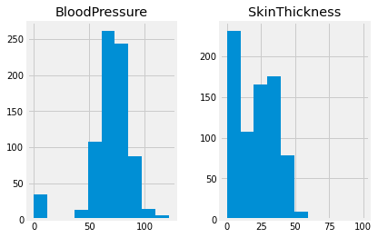

```python
df[['BloodPressure','SkinThickness']].hist()
```

```python
df[['BloodPressure_new','SkinThickness_new']]= std_scal.fit_transform(df[['BloodPressure','SkinThickness']])
```

```python
df.head()
```

|  | Pregnancies | Glucose | BloodPressure | SkinThickness | Insulin | BMI | DiabetesPedigreeFunction | Age | Outcome | Pregnancies_new | Glucose_new | BloodPressure_new | SkinThickness_new |
| --- | --- | --- | --- | --- | --- | --- | --- | --- | --- | --- | --- | --- | --- |
| 0 | 0.352941 | 0.743719 | 72 | 35 | 0 | 33.6 | 0.627 | 50 | 1 | 0.352941 | 0.743719 | 0.149641 | 0.907270 |
| 1 | 0.058824 | 0.427136 | 66 | 29 | 0 | 26.6 | 0.351 | 31 | 0 | 0.058824 | 0.427136 | -0.160546 | 0.530902 |
| 2 | 0.470588 | 0.919598 | 64 | 0 | 0 | 23.3 | 0.672 | 32 | 1 | 0.470588 | 0.919598 | -0.263941 | -1.288212 |
| 3 | 0.058824 | 0.447236 | 66 | 23 | 94 | 28.1 | 0.167 | 21 | 0 | 0.058824 | 0.447236 | -0.160546 | 0.154533 |
| 4 | 0.000000 | 0.688442 | 40 | 35 | 168 | 43.1 | 2.288 | 33 | 1 | 0.000000 | 0.688442 | -1.504687 | 0.907270 |

```
array([[<AxesSubplot:title={'center':'BloodPressure_new'}>,
        <AxesSubplot:title={'center':'SkinThickness_new'}>]], dtype=object)
```

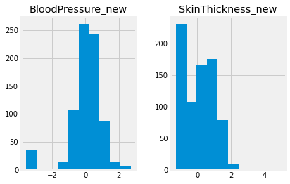

```python
df[['BloodPressure_new','SkinThickness_new']].hist()
```

# RobustScaler

### If there are outliers, use RobustScaler(). Alternatively you could remove the outliers and use either of the above 2 scalers (choice depends on whether data is normally distributed)

```python
from sklearn.preprocessing import RobustScaler
```

```python
Ro_scaler = RobustScaler()
```

```python
df[['Insulin','BMI']]= Ro_scaler.fit_transform(df[['Insulin','BMI']])
```

```
array([[<AxesSubplot:title={'center':'Insulin'}>,
        <AxesSubplot:title={'center':'BMI'}>]], dtype=object)
```

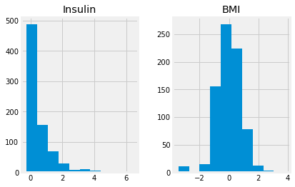

```python
df[['Insulin','BMI']].hist()
```

```python
df.head()
```

|  | Pregnancies | Glucose | BloodPressure | SkinThickness | Insulin | BMI | DiabetesPedigreeFunction | Age | Outcome | Pregnancies_new | Glucose_new | BloodPressure_new | SkinThickness_new |
| --- | --- | --- | --- | --- | --- | --- | --- | --- | --- | --- | --- | --- | --- |
| 0 | 0.352941 | 0.743719 | 72 | 35 | -0.239686 | 0.172043 | 0.627 | 50 | 1 | 0.352941 | 0.743719 | 0.149641 | 0.907270 |
| 1 | 0.058824 | 0.427136 | 66 | 29 | -0.239686 | -0.580645 | 0.351 | 31 | 0 | 0.058824 | 0.427136 | -0.160546 | 0.530902 |
| 2 | 0.470588 | 0.919598 | 64 | 0 | -0.239686 | -0.935484 | 0.672 | 32 | 1 | 0.470588 | 0.919598 | -0.263941 | -1.288212 |
| 3 | 0.058824 | 0.447236 | 66 | 23 | 0.499018 | -0.419355 | 0.167 | 21 | 0 | 0.058824 | 0.447236 | -0.160546 | 0.154533 |
| 4 | 0.000000 | 0.688442 | 40 | 35 | 1.080550 | 1.193548 | 2.288 | 33 | 1 | 0.000000 | 0.688442 | -1.504687 | 0.907270 |

```python
df.head()
```

|  | Pregnancies | Glucose | BloodPressure | SkinThickness | Insulin | BMI | DiabetesPedigreeFunction | Age | Outcome | Pregnancies_new | Glucose_new | BloodPressure_new | SkinThickness_new |
| --- | --- | --- | --- | --- | --- | --- | --- | --- | --- | --- | --- | --- | --- |
| 0 | 0.352941 | 0.743719 | 72 | 35 | -0.239686 | 0.172043 | 0.627 | 50 | 1 | 0.352941 | 0.743719 | 0.149641 | 0.907270 |
| 1 | 0.058824 | 0.427136 | 66 | 29 | -0.239686 | -0.580645 | 0.351 | 31 | 0 | 0.058824 | 0.427136 | -0.160546 | 0.530902 |
| 2 | 0.470588 | 0.919598 | 64 | 0 | -0.239686 | -0.935484 | 0.672 | 32 | 1 | 0.470588 | 0.919598 | -0.263941 | -1.288212 |
| 3 | 0.058824 | 0.447236 | 66 | 23 | 0.499018 | -0.419355 | 0.167 | 21 | 0 | 0.058824 | 0.447236 | -0.160546 | 0.154533 |
| 4 | 0.000000 | 0.688442 | 40 | 35 | 1.080550 | 1.193548 | 2.288 | 33 | 1 | 0.000000 | 0.688442 | -1.504687 | 0.907270 |

```python
org_data = pd.read_csv("diabetes.csv")
org_data.head()
```

|  | Pregnancies | Glucose | BloodPressure | SkinThickness | Insulin | BMI | DiabetesPedigreeFunction | Age | Outcome |
| --- | --- | --- | --- | --- | --- | --- | --- | --- | --- |
| 0 | 6 | 148 | 72 | 35 | 0 | 33.6 | 0.627 | 50 | 1 |
| 1 | 1 | 85 | 66 | 29 | 0 | 26.6 | 0.351 | 31 | 0 |
| 2 | 8 | 183 | 64 | 0 | 0 | 23.3 | 0.672 | 32 | 1 |
| 3 | 1 | 89 | 66 | 23 | 94 | 28.1 | 0.167 | 21 | 0 |
| 4 | 0 | 137 | 40 | 35 | 168 | 43.1 | 2.288 | 33 | 1 |